# Parametric statistical tests

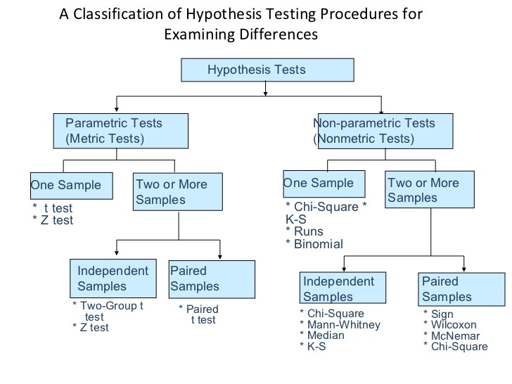

```python
from IPython.display import Image
Image("images/statistical_test.jpg")
```

**Parametric statistics** is a branch of statistics which assumes that sample data comes from a population that can be adequately modelled by a probability distribution that has a fixed set of parameters.

- Statistical significance measures how likely it would be to observe what we observed, assuming the null hypothesis is true.
- A parametric statistical test makes an assumption about the population parameters and the distributions that the data came from.
- Parametric tests make certain assumptions about a data set; namely, that the data are drawn from a population with a specific (normal) distribution. Non-parametric tests make fewer assumptions about the data set.
- The majority of elementary statistical methods are parametric, and parametric tests generally have higher statistical power. If the necessary assumptions cannot be made about a data set, non-parametric tests can be used.

For example:

- $z$ tests
- $t$ tests
- and ANOVA tests,  
  which assume data is from a normal distribution.

Before discussing the details of the parametric statistical tests, we should know

- Central limit theorem
- Distributon of population and sample
- normal distribution and $t$-distribution

```python
import numpy as np
from scipy.stats import norm
import matplotlib.pyplot as plt
```

## Central Limit Theorem

Let $\{X_1, \cdots, X_n\}$ be a random sample of size n—that is, a sequence of independent and identically distributed random variables drawn from a distribution of expected value given by $\mu$ and finite variance given by $\sigma^2$.

Suppose we are interested in the **sample average**, $$ S_n = \dfrac{1}{n}\sum^n_i X_i $$ of these random variables.

For large enough $n$, the distribution of the **sample average** $S_n$ is close to the normal distribution with mean $\mu$ and variance $\sigma^2/n$.

Proof :

- The mean of the **sample average** is given by $$ E(S_n) = E(\dfrac{1}{n}\sum^n_i X_i) =\dfrac{1}{n}\sum^n_i E(X_i) = \dfrac{1}{n}\sum^n_i \mu = \mu. $$
- The variance of the **sample average** is given by $$ Var(S_n) = Var(\dfrac{1}{n}\sum^n_i X_i)=\dfrac{1}{n^2}\sum^n_i Var(X_i) = \dfrac{1}{n^2}\sum^n_i \sigma^2 =\dfrac{1}{n}\sigma^2. $$

## Distributions of population and sample

Let $\{X_1, \ldots, X_n \}$ be independent and identically distributed as $N(\mu, \sigma^2)$, i.e. this is a sample of size $n$ from a normally distributed population with expected mean value$\mu$ and variance $\sigma^2$.

Let

$$ \bar X = \frac 1 n \sum_{i=1}^n X_i $$

be the **sample mean** and let

$$ S^2 = \frac 1 {n-1} \sum_{i=1}^n (X_i - \bar X)^2 $$

be the sample variance.

- Then the random variable (called test statistic) $$ z = \frac{ \bar X - \mu } { \sigma /\sqrt{n}} $$

has a standard normal distribution (i.e. normal with expected value 0 and variance 1)

- the random variable (called test statistic) $$ t = \frac{ \bar X - \mu} {S /\sqrt{n}}, $$ has a Student's **$t$-distribution with $\nu=n-1$ degrees of freedom**, where $S$ has been substituted for $\sigma$. The numerator and the denominator in the preceding expression are independent random variables despite being based on the same sample $\{X_1,\ldots,X_n\}$.

## $t$-distribution

The student's $t$-distribution''' has the probability density function given by

$$ f(t) = \frac{\Gamma(\frac{\nu+1}{2})} {\sqrt{\nu\pi}\,\Gamma(\frac{\nu}{2})} \left(1+\frac{t^2}{\nu} \right)^{\!-\frac{\nu+1}{2}}, $$

where $\nu$ is the number of degrees of freedom and $\Gamma$ is thr gamma function.

For large values of $\nu (\ge30)$, the $f(t)$ becomes closely the standarized normal distribution

$$ f(t) \to \dfrac{1}{(2\pi)^{1/2}} e^{-t^2/2}. $$

# The Z-test ($\sigma^2$ is known)

- It is any statistical test for which **the distribution of the test statistic under the null hypothesis can be approximated by a normal distribution**.
- Because of the **central limit theorem, many test statistics are approximately normally distributed for large samples**.
- Proportion test belongs to z-tests because the parameters (the variance $\sigma$ of the random variables is known) for the distributions are known and given by $$ \mu = p, \quad \sigma^2 = p (1-p). $$
- One can use the proportional z-test to carry out AB test.
- The test statistic for the **average sample** is a z-score (z): $$ z = \dfrac{\widehat \mu - \mu}{\sigma/\sqrt{n}}= \dfrac{\widehat p - p_0}{\sigma/\sqrt{n}} $$

where

- $p_0$ is the proportion rate of the population in the Null Hyperthesis.
- $\widehat p$ is the proportion rate of the sample.
- test if the proportion rate of the sample is equal to that of the population. In other words, using the sample data to test the claim on the parameters of the normal distributinon for the population.

## One sample case of the $Z$-test

```
The sample mean=100.22008648426015 and sample variance=106.8650925551021
```

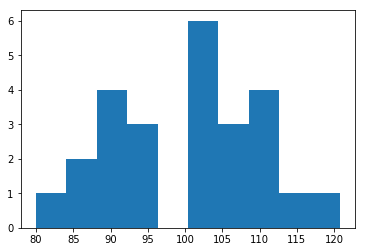

```python
# generate a set of random variables from the normal distribution
# N(mu=100, sigma=10)
data = 10*np.random.randn(25)+100 # mu=100, sigma=10
plt.hist(data)
print("The sample mean={} and sample variance={}".format(data.mean(),data.var()))
```

```python
# build a ztest function to test the mean value

def ztest4mean(data,mu_0,var_0,alpha,sides):
    """
    data -- an array of the sample data
    mu_0 -- the null hypothesis value for the (claim) mean
    var_0 -- the known variance (sigma^2) of the population
    alpha -- confidence level
    sides -- 1 for one-tail; 2 for two-tail test
    """

    # sample size
    n = len(data)

    # sample mean
    mean = data.mean()

    # known variance of the population
    s2 = np.sqrt(var_0/n)

    if abs(s2)<1.e-20:
        print("error in the data")
    else:
        stats = abs(mean-mu_0)/s2  # also called z-score

    p_value = norm.sf(abs(stats))*sides # sf(x, loc=0, scale=1) returns the p value


    if p_value > alpha:
        print('Fail to reject H0')
    else:
        print('Reject H0')

    return stats,p_value
```

```python
# hypothesis on the mean
mu_0 = 105

# known variance of the population
var_0 = 100

# confidence level: 1-\alpha
alpha=0.05

# one-tail or two-tail
sides = 2

stats,p = ztest4mean(data,mu_0,var_0,alpha,sides)
print("z score={}, p value={}".format(stats,p))
```

```
Reject H0
z score=2.389956757869925, p value=0.016850356621262684
```

```python
# hypothesis on the mean
mu_0 = 101

# known variance of the population
var_0 = 100

# confidence level: 1-\alpha
alpha=0.05

# one-tail or two-tail
sides = 2

stats,p = ztest4mean(data,mu_0,var_0,alpha,sides)
print("z score={}, p value={}".format(stats,p))
```

```
Fail to reject H0
z score=0.3899567578699248, p value=0.6965685228228696
```

## One Proportion Z-Test example

Analysis: the test statistic $$ z = \dfrac{(p^G - p^G_0)}{\sigma/\sqrt{n}} $$ follows the normal distribution $N(0,1)$, where $\sigma^2=p^G_0 (1-p^G_0)=0.25$ due to the binomial distribution with $n=1$ (or called Bernoulli distribution).

**Attention:** All Bernoulli distributions are binomial distributions, but most binomial distributions are not Bernoulli distributions.

If

$$ 𝑋=\begin{cases} 1, & {\rm with ~~ probability} ~~ p,\\ 0, & {\rm with ~~ probability} ~~1−p, \end{cases} $$

then the probability distribution of the random variable $𝑋$ is a Bernoulli distribution.

If $𝑋=𝑋_1+ \cdots +𝑋_𝑛$ and each of $𝑋_1,\cdots, 𝑋_𝑛$ has a Bernoulli distribution with the same value of $𝑝$ and they are independent, then $𝑋$ has a binomial distribution, and the possible values of $𝑋$ are $\{0,1,2,3,\cdots,𝑛\}$.

If $𝑛=1$, then that binomial distribution is a Bernoulli distribution.

```python
def ztest4Proportion(size,prob_s,prob_0,alpha,sides):
    """
    prob_s -- sample proportion
    prob_0 -- the null hypothesis value for the proportion
    alpha -- confidence level
    sides -- 1 for one-tail; 2 for two-tail test
    """

    sigma = np.sqrt(prob_0*(1.0-prob_0))/np.sqrt(size)
    stats = abs(prob_s-prob_0)/sigma  # also called z-score

    p_value = norm.sf(abs(stats))*sides # sf(x, loc=0, scale=1) returns the p value



    if p_value > alpha:
        print('Fail to reject H0')
    else:
        print('Reject H0')

    return stats,p_value
```

```python
stats,p_value  = ztest4Proportion(100,0.45,0.5,0.05,1)

print("stats={}, p value={}".format(stats,p_value))
```

```
Fail to reject H0
stats=0.9999999999999998, p value=0.15865525393145707
```

## Using the z-test for AB test

Outline for A/B Tests

- Set up the experiment.
- Run the test and record the success rate for each group.
- Plot the distribution of the difference between the two samples.
- Calculate the statistical power.
- Evaluate how sample size affects A/B tests.

Control Group (A) and Test Group (B):

- Typically, the total number of users participating in the A/B test make up a small percentage of the total amount of users.
- Users are **randomly selected and assigned** to either a control group or a test group.
- The sample size that you decide on will determine how long you might have to wait until you have collected enough.

```python
np.random.randn(10)
```

```
array([ 3.30764573,  0.03611436,  0.20450759, -0.98179986,  1.68980069,
        0.28666478, -0.97081833,  0.44759566, -0.53780763,  0.15591608])
```

```python
def generate_data4ABtest(n_A, n_B):

    assert min(n_A, n_B) > 40


    rand1 = np.random.randn(n_A)
    data1 = np.array(rand1>0.5).astype(int)


    rand2 = np.random.randn(n_B)
    data2 = np.array(rand2>0.5).astype(int)

    return data1.tolist(),data2.tolist()
```

```python
n_A = 150
n_B = 150
data1,data2=generate_data4ABtest(n_A, n_B)
```

```python
A_conv_rate = data1.count(1)/len(data1)
B_conv_rate = data2.count(1)/len(data2)
A_conv_rate,B_conv_rate
```

```
(0.34, 0.25333333333333335)
```

According to the properties of the Bernoulli distribution for $X$, the mean and variance are as follows: $$ E(X) = p, ~~ var(X)=p(1-p). $$

According to the **central limit theorem**, by calculating many sample means we can approximate the true mean of the population, $\mu$, from which the data for the control group was taken. The distribution of the sample means, $p$, will be normally distributed around the true mean $\mu$ with a standard deviation equal to the standard error of the mean.

$$ \widehat p \sim N(\mu=p, \sigma^2/n=\dfrac{p(1-p)}{n}). $$

For two sample cases in the AB test, the null hypothesis $H_0$

- $H_0$: $p_A-p_B=0$
- $H_1$: $p_A \neq p_B$

The variance of the mean: $$ \sigma^2/n = \dfrac{p_A(1-p_A)}{n_A} + \dfrac{p_B(1-p_B)}{n_B} = \widehat p(1-\widehat p) (\dfrac{1}{n_A}+\dfrac{1}{n_B}),~~ \widehat p = \dfrac{p_An_A + p_Bn_B}{n_A+n_B}. $$

Therefore the test statistic is $$ z = \dfrac{p_A-p_B}{\sigma/\sqrt{n}} $$

```python
def ztest4ABtest(p1, p2, n1, n2, alpha, sides):


    """
        propotional test for the same sample size.

        p1 -- prob for A
        p2 -- prob for B
        alpha -- confidence level
        sides -- 1 for one-tail; 2 for two-tail test
        """

    # avoid singularity problem

    assert n1 > 0.1  and n2 > 0.1

    # mean proportion
    prob = (p1*n1 + p2*n2)/ (n1 + n2) #  or mean = B_conv_rate

    # standard error
    SE = np.sqrt(prob*(1-prob)*(1/n1 + 1/n2))

    stats = abs(p1-p2)/SE

    p_value = norm.sf(abs(stats))*sides # sf(x, loc=0, scale=1) returns the p value

    if p_value > alpha:
        print('Fail to reject the H0: namely two performaces are similar at the C.L. of {}%'.format(100*(1-alpha)))
    else:
        print('Reject H0: namely, two performances are different at the C.L. of {}%'.format(100*(1-alpha)))

    return stats,p_value
```

```python
stats,p = ztest4ABtest(A_conv_rate,B_conv_rate,n_A,n_B,0.05, 2)

print("stats={}, p value={}".format(stats,p))
```

```
Fail to reject the H0: namely two performaces are similar at the C.L. of 95.0%
stats=1.6431141992548661, p value=0.10035930756073116
```

The AB test can also be performed using the chi-square test

```python
from scipy.stats import chi2_contingency

data = np.array([[data1.count(1),data1.count(0)],
                 [data2.count(1),data2.count(0)]])

chi,p_value=chi2_contingency(data)[:2]

alpha=0.05
if p_value > alpha:
    print('Fail to reject H0')
else:
    print('Reject H0')

print("stats={}, p value={}".format(stats,p))
```

[output not shown]

# The t-test ($\sigma^2$ is unknown)

Assumptions on the data:

- indepdendent
- sample from normal distribution
- variance of population is unknown

## $t$-test mean for one sample

- **one sample** of whether the mean of a population has a value specified in a null hypothesis.

use the statistic method **ttest_1samp()**

```python
# build a ztest function to test the mean value

from scipy  import stats

def ttest4mean(data,mu_0,alpha,sides):
    """
    data -- an array of the sample data
    mu_0 -- the null hypothesis value for the (claim) mean
    alpha -- confidence level
    sides -- 1 for one-tail; 2 for two-tail test
    """

    # sample variance: degree-of-freedom=n-1
    sample_var = data.var(ddof=1)

    # sample size
    n = len(data)

    # degree of freedom
    dof = n - 1

    # sample mean
    mean = data.mean()


    s2 = np.sqrt(sample_var/n)
    if abs(s2)<1.e-20:
        print("error in the data")
    else:
        t_score = abs(mean-mu_0)/s2  # also called z-score

    p_value = stats.t.sf(np.abs(t_score), dof)*sides



    if p_value > alpha:
        print('Fail to reject H0')
    else:
        print('Reject H0')

    return t_score,p_value
```

```python
# generate data
data = 10*np.random.randn(25)+100 # mu=100, sigma=10
```

```python
# hypothesis on the mean
mu_0 = 105

# confidence level: 1-\alpha
alpha=0.05

# one-tail or two-tail
sides = 2

t_score,p = ttest4mean(data,mu_0,alpha,sides)
print("t score={}, p value={}".format(t_score,p))
```

```
Fail to reject H0
t score=1.6605334792862882, p value=0.1098178774712533
```

**Use package from scipy.stats**

```python
from scipy.stats import ttest_1samp
```

```python
# scipy.stats.ttest_1samp(a, popmean, axis=0, nan_policy='propagate')[source]
# Returns
# -------
# statistic : float or array
#     t-statistic
# pvalue : float or array
#     two-tailed p-value

mu_0 = 105
stats,p = ttest_1samp(data,mu_0)

alpha=0.05

if p > alpha:
    print('t score={}, p value={}'.format(stats,p))
    print('Same distribution (fail to reject H0)')
else:
    print('t score={}, p value={}'.format(stats,p))
    print('Different distribution (reject H0)')
```

```
t score=-1.6605334792862882, p value=0.1098178774712533
Same distribution (fail to reject H0)
```

## test two independent samples

These tests are often referred to as "unpaired" or "independent samples" ''t''-tests, as they are typically applied when the statistical units underlying the two samples being compared are non-overlapping.

- **Student's t-test**: variances of the two populations are assumed to be equal
- **Welch's t-test**: variances of the two populations are NOT assumed to be equal

https://pythonfordatascience.org/welch-t-test-python-pandas/

Welch’s t-test Assumptions:

- The independent variable (IV) is categorical with at least two levels (groups)
- The dependent variable (DV) is continuous which is measured on an interval or ratio scale
- The distribution of the two groups should follow the normal distribution

**Keep in Mind**: Always use Welch’s t-testto avoid checking if the two samples are from the populations with the same variances.

- The statistic $t$:

$$ t \quad = \quad {\; \overline{X}_1 - \overline{X}_2 \; \over \sqrt{ \; {s_1^2 \over N_1} \; + \; {s_2^2 \over N_2} \quad }} $$

where $\overline{X}_1, s_1^2$ and $N_1$ are the 1st sample mean, sample variance and sample size, respectively.

The degrees of freedom (statistics) $\nu$ associated with this variance estimate is approximated using the Welch–Satterthwaite equation:

$$ \nu \quad \approx \quad {{\left( \; {s_1^2 \over N_1} \; + \; {s_2^2 \over N_2} \; \right)^2 } \over { \quad {s_1^4 \over N_1^2 \nu_1} \; + \; {s_2^4 \over N_2^2 \nu_2 } \quad }} $$

Here

- $\nu_1 = N_1-1$, the degrees of freedom associated with the first variance estimate.
- $\nu_2 = N_2-1$, the degrees of freedom associated with the 2nd variance estimate.

To conduct a Welch’s t-test, one needs to use the **stats.ttest_ind()** method while passing **equal_var=False** in the argument.

```python
data1 = 5* np.random.randn(100)+50
data2 = 5* np.random.randn(100)+52
```

```python
# scipy.stats.ttest_ind (a, b, axis=0, equal_var=True, nan_policy='propagate')

from scipy.stats import ttest_ind

stats,p = ttest_ind(data1,data2,equal_var=False)

alpha=0.05

print("Welch's t-test={}\n".format(stats))
print("Welch's p-value={}\n".format(p))

if p > alpha:
    print('Same distribution (fail to reject H0)')
else:
    print('Different distribution (reject H0)')
```

```
Welch's t-test=-1.0405845313457198

Welch's p-value=0.2993705884017579

Same distribution (fail to reject H0)
```

```python
def welch_ttest(x, y):

    ## Welch-Satterthwaite Degrees of Freedom ##
    dof = (x.var()/x.size + y.var()/y.size)**2 / ((x.var()/x.size)**2 / (x.size-1) + (y.var()/y.size)**2 / (y.size-1))

    t, p = ttest_ind(x, y, equal_var = False)

    print("\n",
          f"Welch's t-test= {t:.4f}", "\n",
          f"p-value = {p:.4f}", "\n",
          f"Welch-Satterthwaite Degrees of Freedom= {dof:.4f}")

welch_ttest(data1, data2)
```

[output not shown]

## Two paired samples

For example:

The sample one $\{X_1,X_2,\cdots,X_n\}$ and sample two $\{Y_1,Y_2,\cdots,Y_n\}$ are paired. In this case, one can creat a sample as the difference between them, namely

$\{X_1 - Y_1, X_2-Y_2,\cdot, X_n-Y_n\}$, for which, one can use one-sample $t$-test to test if the difference in the two samples follows the normal distribution with mean $\mu=0$ and variance $s^2$.

# ANalysis Of VAriance (ANOVA)

An Analysis of Variance Test or an ANOVA is a generalization of the t-tests to more than 2 groups.

Our null hypothesis states that there are equal means in the populations from which the groups of data were sampled. $$ \mu_1 =\mu_2= \cdots =\mu_n $$

for $n$ groups of data. Our alternative hypothesis would be that any one of the equivalences in the above equation fail to be met.

The ANOVA assumptions:

- Normality
- Homogeneity of variance
- Independent observations

The following example is from https://pythonfordatascience.org/anova-python/

```python
import pandas as pd
import scipy.stats as stats
import researchpy as rp
import statsmodels.api as sm
from statsmodels.formula.api import ols

import matplotlib.pyplot as plt

# Loading data
df = pd.read_csv("https://raw.githubusercontent.com/Opensourcefordatascience/Data-sets/master/difficile.csv")
df.drop('person', axis= 1, inplace= True)

# Recoding value from numeric to string
df['dose'].replace({1: 'placebo', 2: 'low', 3: 'high'}, inplace= True)

# Gettin summary statistics
rp.summary_cont(df['libido'])
```

|  | Variable | N | Mean | SD | SE | 95% Conf. | Interval |
| --- | --- | --- | --- | --- | --- | --- | --- |
| 0 | libido | 15.0 | 3.466667 | 1.76743 | 0.456349 | 2.487896 | 4.445437 |

```python
rp.summary_cont(df['libido'].groupby(df['dose']))
```

| dose | N | Mean | SD | SE | 95% Conf. | Interval |
| --- | --- | --- | --- | --- | --- | --- |
| high | 5 | 5.0 | 1.581139 | 0.707107 | 3.450484 | 6.549516 |
| low | 5 | 3.2 | 1.303840 | 0.583095 | 1.922236 | 4.477764 |
| placebo | 5 | 2.2 | 1.303840 | 0.583095 | 0.922236 | 3.477764 |

```python
stats.f_oneway(df['libido'][df['dose'] == 'high'],
             df['libido'][df['dose'] == 'low'],
             df['libido'][df['dose'] == 'placebo'])
```

```
F_onewayResult(statistic=5.11864406779661, pvalue=0.024694289538222603)
```

```python
results = ols('libido ~ C(dose)', data=df).fit()
results.summary()
```

OLS Regression Results

| Dep. Variable: | libido | R-squared: | 0.460 |
| --- | --- | --- | --- |
| Model: | OLS | Adj. R-squared: | 0.370 |
| Method: | Least Squares | F-statistic: | 5.119 |
| Date: | Sat, 23 Mar 2019 | Prob (F-statistic): | 0.0247 |
| Time: | 19:42:25 | Log-Likelihood: | -24.683 |
| No. Observations: | 15 | AIC: | 55.37 |
| Df Residuals: | 12 | BIC: | 57.49 |
| Df Model: | 2 |  |  |
| Covariance Type: | nonrobust |  |  |

|  | coef | std err | t | P>\|t\| | [0.025 | 0.975] |
| --- | --- | --- | --- | --- | --- | --- |
| Intercept | 5.0000 | 0.627 | 7.972 | 0.000 | 3.634 | 6.366 |
| C(dose)[T.low] | -1.8000 | 0.887 | -2.029 | 0.065 | -3.732 | 0.132 |
| C(dose)[T.placebo] | -2.8000 | 0.887 | -3.157 | 0.008 | -4.732 | -0.868 |

| Omnibus: | 2.517 | Durbin-Watson: | 2.408 |
| --- | --- | --- | --- |
| Prob(Omnibus): | 0.284 | Jarque-Bera (JB): | 1.108 |
| Skew: | 0.195 | Prob(JB): | 0.575 |
| Kurtosis: | 1.727 | Cond. No. | 3.73 |

Warnings:  
[1] Standard Errors assume that the covariance matrix of the errors is correctly specified.

Overall the model is significiant, F(2,12)= 5.12, p = 0.0247. This tells us that there is a significant difference in the group means.

```python
aov_table = sm.stats.anova_lm(results, typ=2)
aov_table
```

|  | sum_sq | df | F | PR(>F) |
| --- | --- | --- | --- | --- |
| C(dose) | 20.133333 | 2.0 | 5.118644 | 0.024694 |
| Residual | 23.600000 | 12.0 | NaN | NaN |

```python
stats.levene(df['libido'][df['dose'] == 'placebo'],
             df['libido'][df['dose'] == 'low'],
             df['libido'][df['dose'] == 'high'])
```

```
LeveneResult(statistic=0.11764705882352934, pvalue=0.8900225182757423)
```

Levene’s test for homogeneity of variance is not significant which indicates that the groups have equal variances.

# Last words

In order to be able to use parameteric statistic tests, one should first test the assumptions:

- **Normality**:

It assumes that the continuous variables to be used in the analysis are normally distributed. Normal distributions are symmetric around the center (a.k.a., the mean) and follow a ‘bell-shaped’ distribution. Normality is typically assessed in the examination of mean differences (e.g., t-tests and analyses of variance – ANOVAs/MANOVAs) and prediction analyses (e.g., linear regression analyses). Normality can be examined by several methods, two of which are the Kolmogorov Smirnov (KS) test and the examination of skew and kurtosis. The KS test utilizes the z test statistic, and if the corresponding p value is less than .05 (statistical significance), then the assumption of normality is not met. Also, normality can be defined as skew below ± 2.0 and kurtosis below ± 7.0, and if the observed values exceed these boundaries, then the assumption of normality is not met.

Python packages:

1. scipy.stats.kstest(data,'norm')
2. scipy.stats.shapiro(data) or scipy.stats.normaltest(datga)
3. use QQ plot for residual analysis
- **Linearity** (correlated or not):

It refers to a linear, or straight line, relationship between the independent variable(s) and the dependent variable. If the assumption of linearity is not met, then predictions may be inaccurate. Linearity is typically assessed in Pearson correlation analyses and regression analyses. Linearity can be assessed by the examination of scatter plots.

- **Equality of variance** (variance equal or not)

It refers to equal variances across different groups or samples. Equality of variance is usually examined when assessing for mean differences on an independent grouping variable (e.g., t-tests and analyses of variance – ANOVAs/MANOVAs). Equality of variance can be assessed by utilizing Levene’s test for each continuous, dependent variable. Levene’s test utilizes the F test, and if the corresponding p value is less than .05 (statistical significance), then the assumption of equality of variance is not met.

Python packages:

1. scipy.stats.barlett(data1, data2)
2. scipy.stats.levene(data1, data2, center={'mean'}) (recommend!)
3. scipy.stats.flinger(data1, data2, center={'mean'})